# Understanding `data.table` a little better

As of late, I have used the `data.table` package to do some of my data wrangling. It has been a fun adventure (the nerd type of fun), and was made more meaningful with the renewed development of the `dtplyr` package by Hadley Wickham and co. I introduce some of the different behavior of `data.table` [here](https://tysonstanley.github.io//jekyll/update/2019/07/12/datatable/).

This post is designed to help me understand more about how `data.table` works in regards to memory and speed. This will assess the *modify-by-reference* behavior as compared to the modify-by-copy that Hadley references in Advanced R’s [memory chapter](http://adv-r.had.co.nz/memory.html).

Throughout this post, I use the terms **efficient** and **speed**.

1. *Efficient*: refers to how much memory is used to perform a function.
2. *Speed*: refers to how quickly the function runs.

We’ll be assessing these two things to understand more about `data.table` and `dplyr` (as well as base R).

## TL;DR

In cases of adding a variable, filtering rows, and summarizing data, both `dplyr` and `data.table` perform very well.

1. Base R, `dplyr`, and `data.table` perform similarly when adding a single variable to an already copied data set.
2. `data.table` is very efficient and quick in filtering.
3. `dplyr` shows great memory efficiency in summarizing, while `data.table` is generally the fastest approach.

If you want the specifics, continue on :)

## Packages

First, we’ll use the following packages to further understand R, `data.table`, and `dplyr`.

```r
library(bench)      # assess speed and memory
library(data.table) # data.table for all of its stuff
library(dplyr)      # compare it to data.table
library(lobstr)     # assess the process of R functions
```

And we’ll set a random number seed.

```r
set.seed(84322)
```

## Example Data

We’ll use the following data table for this post.

```r
dt <- data.table(
  grp = sample(c(1,2,3), size = 1e6, replace = TRUE) %>% factor,
  x = rnorm(1e6),
  y = runif(1e6)
)
dt
```

```
##          grp           x          y
##       1:   1 -0.38947156 0.54057612
##       2:   2 -1.30538661 0.39913045
##       3:   1 -1.31999432 0.31704868
##       4:   1 -0.50988678 0.99807764
##       5:   3  1.95336283 0.14378685
##      ---
##  999996:   1 -0.51576465 0.49866080
##  999997:   1  0.97193922 0.07174214
##  999998:   1 -0.06402822 0.98004497
##  999999:   1 -1.78073054 0.51904927
## 1000000:   3 -0.56124894 0.29423306
```

It is roughly 20 MB and has an address of 0x7f964d754600. We won’t be using this address later on because we’ll be making copies of this data table, but note that an object has a size and an address on your computer.

## Comparisons

Below, I will look at the behavior of `data.table` (compared to base R and `dplyr`) regarding:

1. Adding a variable
2. Filtering rows
3. Summarizing data

Let’s start with the base approaches.

### Base R

The following functions perform, in order, 1) adding a variable, 2) filtering rows, and 3) summarizing data by group using base functionality.

```r
base_mutate <- function(data){
  data$z <- rnorm(1e6)
  data
}
base_filter <- function(data){
  data[data$grp == 1, ]
}
base_summarize <- function(data){
  tapply(data$x, data$grp, mean)
}
```

### `dplyr`

Again, the following functions perform, in order, 1) adding a variable, 2) filtering rows, and 3) summarizing data by group using `dplyr` functions.

```r
dplyr_mutate <- function(data){
  mutate(data, z = rnorm(1e6))
}
dplyr_filter <- function(data){
  filter(data, grp == 1)
}
dplyr_summarize <- function(data){
  summarize(group_by(data, grp), mean(x))
}
```

### `data.table`

```r
dt_mutate <- function(data){
  data[, z := rnorm(1e6)]
}
dt_filter <- function(data){
  data[grp == 1]
}
dt_summarize <- function(data){
  data[, mean(x), by = "grp"]
}
```

## Copies to Benchmark

The data below are copied in order to make the benchmarking more comparable.

```r
df <- copy(dt) %>% as.data.frame()
tbl <- copy(dt) %>% as_tibble()
dt <- copy(dt)
```

## Benchmarking

The following benchmarking tests each situation for the three approaches.

```r
# Adding a variable
bench_base_m  <- bench::mark(base_mutate(df), iterations = 25)
bench_dplyr_m <- bench::mark(dplyr_mutate(tbl), iterations = 25)
bench_dt_m    <- bench::mark(dt_mutate(dt), iterations = 25)
# Filtering rows
bench_base_f  <- bench::mark(base_filter(df), iterations = 25)
bench_dplyr_f <- bench::mark(dplyr_filter(tbl), iterations = 25)
bench_dt_f    <- bench::mark(dt_filter(dt), iterations = 25)
# Summarizing by group
bench_base_s  <- bench::mark(base_summarize(df), iterations = 25)
bench_dplyr_s <- bench::mark(dplyr_summarize(tbl), iterations = 25)
bench_dt_s    <- bench::mark(dt_summarize(dt), iterations = 25)
```

## Memory Usage (Efficiency)

We will visualize the memory allocated for each approach, using `ggplot2` and `cowplot` packages.

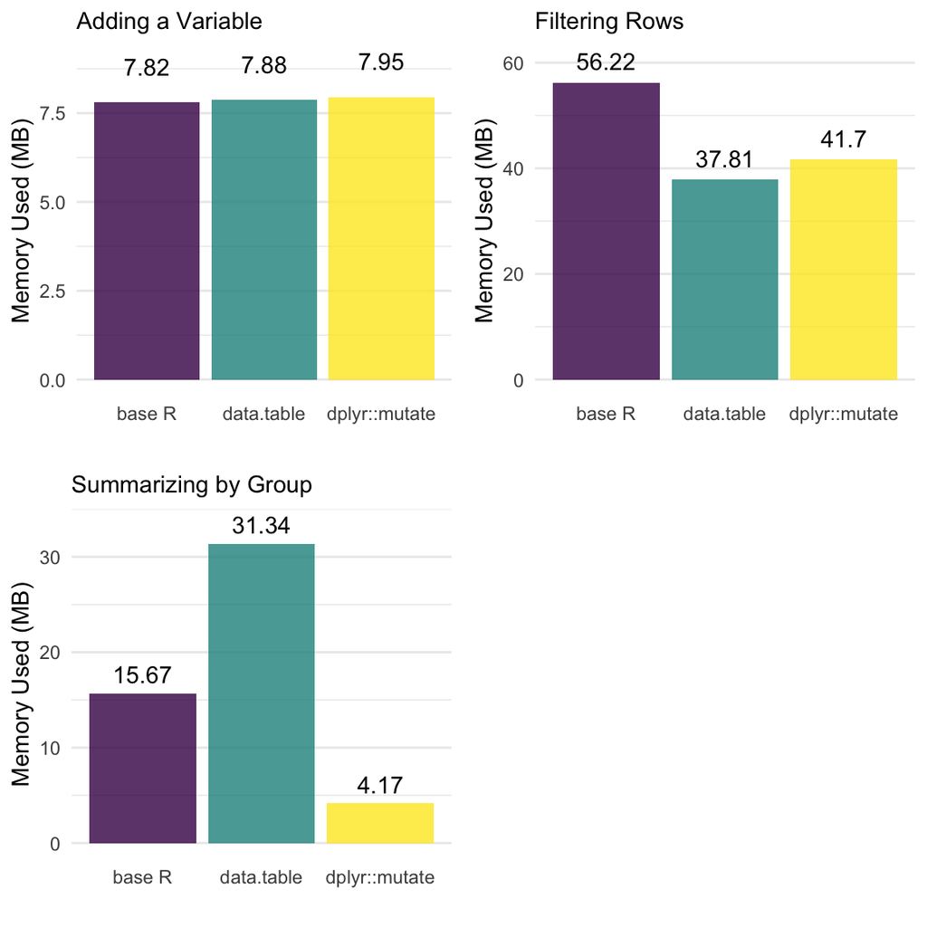

Definitely some things worth noting across the approaches.

1. There are no meaningful differences when adding a variable.
2. `data.table` is the most efficient when filtering rows.
3. `dplyr` is far more efficient when summarizing by group while `data.table` was the least efficient.

## Speed

Below, we next look at the speed

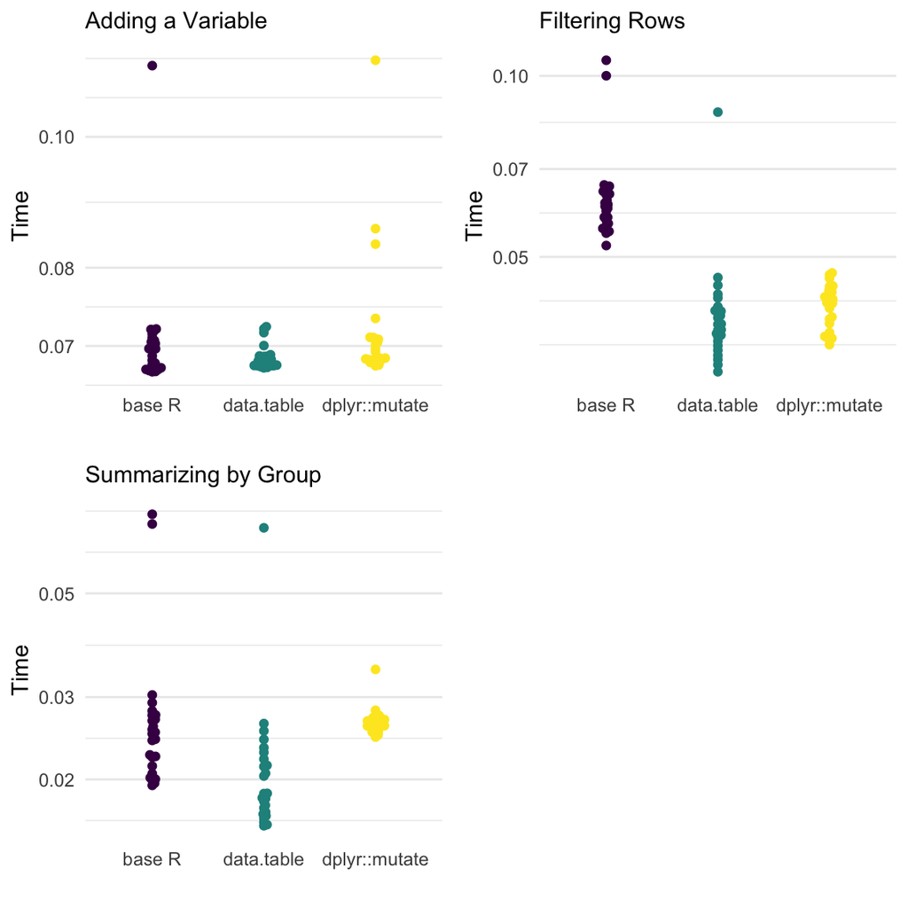